# ch08. artificial neural networks(ANN)

Jeong Eun Lee

2021 11 3, 2021 11 10

- 신경망(artificial neural networks, ANN) : 동물의 뇌신경계를 모방하여 분류 또는 예측을 위해 만들어진 모형
  - 입력 : 개별 신호의 강도에 따라 가중
  - 활성함수 : 출력 계산
  - 오차가 작아지는 방향으로 가중치가 조정됨
  - 장점
    1. 변수의 수가 많거나 입출력 변수 간 복잡한 비선형 관계가 존재할 때 유용
    2. 잡음에 대해서도 민감하게 반응하지 않음
  - 단점
    1. 결과에 대한 해석이 쉽지 않음
    2. 은닉층의 수와 은닉노드 수의 결정이 어려움
    3. 초깃값에 따라 전역해가 아닌 지역해로 수렴할 수 있음
    4. 모형이 복잡하면 훈련과정에 시간이 많이 소요될 수 있음
- 단층신경망(퍼셉트론) : 입력층이 은닉층 없이 직접 출력층에 연결
  $$z = w'x + x_0$$
  - 가중치 $w$ : 방향을 나타내는 모수
  - 편의 $w_0$ : 위치를 결정하는 모수
    - 가중치 $w$와 절편 $w_0$는 학습을 통해 오차제곱합이 최소가 되는 방향으로 갱신됨
      - 가중치 $w$ 갱신 방법 실제 $y_i$, 추정 $\hat{y_i}$ $\rightarrow$ 목적함수 $Q = \sum (g_i - \hat{y_i})$ 이 작아지기를 원하고 추정함 $\frac {\partial Q} {\partial w_i} = 0$ 이 되도록 편미분하여 $w$ 값을 구한 후 이 $w$ 값을 이용해서 역으로 적당한 값을 빼주거나 더해주는 방식을 통해 목적함수가 작아지는 방향으로 $w$ 값을 조정함
- 활성함수의 종류 : 부호 / ReLu / 계단 / 시그모이드 / Softmax / tanh / 가우스
  - 시그모이드 : 결과는 연속형이며 $0 \le y \le 1$ $\rightarrow$ 확장 : tanh 함수($-1 \le y \le 1$)
- 통계모형을 신경망으로 표현하기
  1. 다중회귀(MLR) : Q = $\sum (y_i - \hat{y_i})^2$ (SSE) $\rightarrow$ y 연속
  2. logistig reg : Q = cross entropy $\rightarrow$ y 범주(이산)
- 통계 vs 기계학습, 딥러닝
  1. 통계 : $\hat{y} = w_0 + \sum w_ix_i \rightarrow \hat{\beta} = (X'X)^{-1}X'y$ 통계적인 관점에서는 추정 시 이론(최소제곱법)에 근거하여 접근함 계산이 복잡함
  2. 기계학습, 딥러닝 : 데이터를 입력시켜 선형결합식을 만든 후 이 선형결합식이 실제 $y$와 얼마나 차이가 나는지, 이 차이가 최소가 되는 방향으로 가중치를 조정하는 방법을 무한히 반복하는 과정을 거쳐 수렴값을 최종 $w$ 값으로 추정 단순한 로직으로 시행이 가능함

### 예제 1. nnet(){nnet}

```r
library(nnet)
nn.iris = nnet(Species ~ ., data = iris, size = 2, rang = 0.1, decay = 5e-4, maxit = 200)
summary(nn.iris)
```

```
## a 4-2-3 network with 19 weights
## options were - softmax modelling  decay=5e-04
##  b->h1 i1->h1 i2->h1 i3->h1 i4->h1
##   0.41   0.64   1.84  -3.14  -1.53
##  b->h2 i1->h2 i2->h2 i3->h2 i4->h2
##  -8.77  -0.49  -1.37   1.87   3.76
##  b->o1 h1->o1 h2->o1
##  -3.11   9.67  -3.15
##  b->o2 h1->o2 h2->o2
##   6.14  -8.43  -8.58
##  b->o3 h1->o3 h2->o3
##  -3.03  -1.25  11.73
```

```r
library(devtools)
```

```r
source_url('https://gist.githubusercontent.com/Peque/41a9e20d6687f2f3108d/raw/85e14f3a292e126f1454864427e3a189c2fe33f3/nnet_plot_update.r')
```

```
## i SHA-1 hash of file is bf3c7b8ac910823b729e3ce73bb6ab5e6955ad3d
```

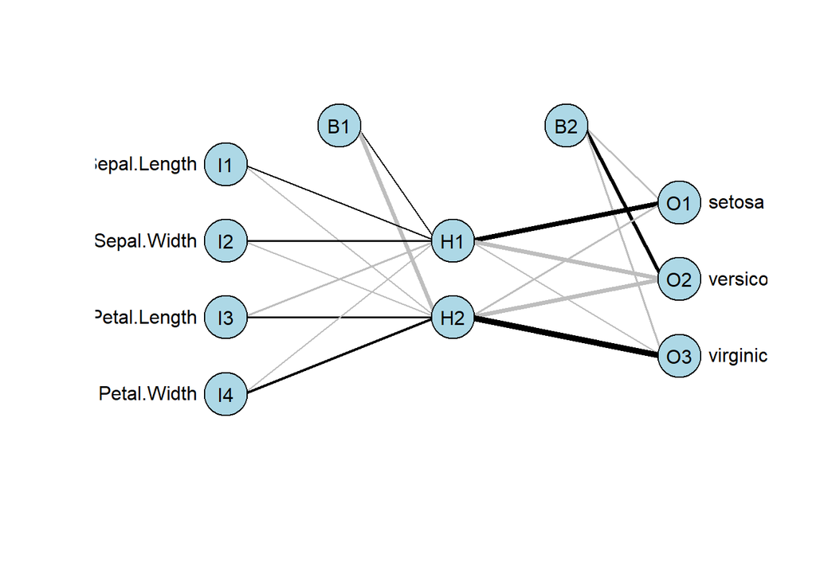

```r
plot.nnet(nn.iris)  # 시각화
```

- size = 은닉층 노드 수
- rang = 초기 랜덤 가중치 범위
- decay = 갱신 폭을 줄이도록 조절하는 모수로 디폴트는 0
- maxit = 최대 반복수로 디폴트는 100
- 데이터를 입력할 때에는 표준화가 다 된 입력자료가 들어가야한다. 그렇지 않으면 차후에 특정변수가 가중이 더 커지는 문제가 발생하여 weight를 동등하게 가져가기 위해 필수 과정이다. ex) zero-one 표준화
- 은닉층 : 복잡한 모형에서는 노드 많이, 단순한 모형에서는 노드 적게
  - but, 불필요하게 많으면 과적합 문제 발생
- 선의 굵기는 연결성의 가중치에 비례한다. 이는 예측력은 매우 뛰어나나, 각 가중치의 의미를 해석하는데에는 어려움이 있어 해석력은 떨어진다.

```r
library(clusterGeneration)
```

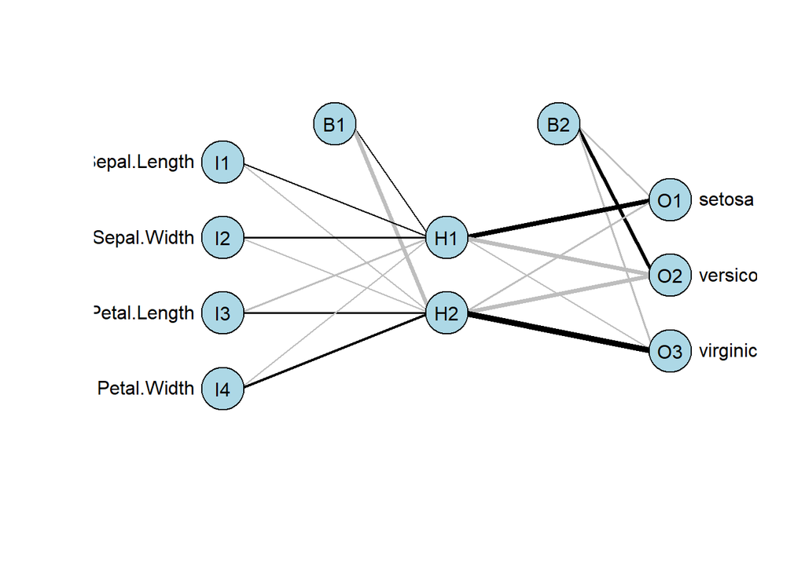

```r
library(scales)
library(reshape)
plot(nn.iris)
```

```r
table(iris$Species, predict(nn.iris, iris, type = "class"))  # 정오분류표
```

```
##
##              setosa versicolor virginica
##   setosa         50          0         0
##   versicolor      0         49         1
##   virginica       0          1        49
```

### 예제 2. neuralnet(){neuralnet}

```r
data(infert, package = "datasets")
str(infert)
```

```
## 'data.frame':    248 obs. of  8 variables:
##  $ education     : Factor w/ 3 levels "0-5yrs","6-11yrs",..: 1 1 1 1 2 2 2 2 2 2 ...
##  $ age           : num  26 42 39 34 35 36 23 32 21 28 ...
##  $ parity        : num  6 1 6 4 3 4 1 2 1 2 ...
##  $ induced       : num  1 1 2 2 1 2 0 0 0 0 ...
##  $ case          : num  1 1 1 1 1 1 1 1 1 1 ...
##  $ spontaneous   : num  2 0 0 0 1 1 0 0 1 0 ...
##  $ stratum       : int  1 2 3 4 5 6 7 8 9 10 ...
##  $ pooled.stratum: num  3 1 4 2 32 36 6 22 5 19 ...
```

```r
library(neuralnet)
# neuralnet() : 역전파 알고리즘을 통해 모형 적합
net.infert = neuralnet(case ~ age + parity + induced + spontaneous, data = infert, hidden = 2,
                       err.fct = "ce", linear.output = FALSE, likelihood = TRUE)
net.infert
```

```
## $call
## neuralnet(formula = case ~ age + parity + induced + spontaneous,
##     data = infert, hidden = 2, err.fct = "ce", linear.output = FALSE,
##     likelihood = TRUE)
##
## $response
##     case
## 1      1
## 2      1
## 3      1
## 4      1
## 5      1
## 6      1
## 7      1
## 8      1
```

[output cut: 1342 more lines]

```r
plot(net.infert)  # 시각화
names(net.infert)  # 추가 정보
```

```
##  [1] "call"                "response"            "covariate"
##  [4] "model.list"          "err.fct"             "act.fct"
##  [7] "linear.output"       "data"                "exclude"
## [10] "net.result"          "weights"             "generalized.weights"
## [13] "startweights"        "result.matrix"
```

```r
net.infert$result.matrix  # 행렬 정보
```

```
##                                  [,1]
## error                    1.248996e+02
## reached.threshold        9.577427e-03
## steps                    1.858000e+03
## aic                      2.757992e+02
## bic                      3.214738e+02
## Intercept.to.1layhid1    5.555909e+00
## age.to.1layhid1         -1.142334e-01
## parity.to.1layhid1       1.697685e+00
## induced.to.1layhid1     -2.125560e+00
## spontaneous.to.1layhid1 -3.243049e+00
## Intercept.to.1layhid2    5.402342e-01
## age.to.1layhid2         -1.547110e+00
## parity.to.1layhid2       6.495060e+00
## induced.to.1layhid2     -3.457026e-02
## spontaneous.to.1layhid2 -1.781992e+02
## Intercept.to.case        3.640176e+00
## 1layhid1.to.case        -5.423041e+00
## 1layhid2.to.case        -4.166946e+01
```

```r
out = cbind(net.infert$covariate, net.infert$net.result[[1]])
dimnames(out) = list(NULL, c("age", "parity", "induced", "spontaneous", "nn-output"))
head(out)
```

```
##      age parity induced spontaneous nn-output
## [1,]  26      6       1           2 0.1545241
## [2,]  42      1       1           0 0.6189195
## [3,]  39      6       2           0 0.1445381
## [4,]  34      4       2           0 0.1539885
## [5,]  35      3       1           1 0.3531780
## [6,]  36      4       2           1 0.4921773
```

- hidden = 은닉층의 노드 수
- err.fct = 목적함수, 디폴트 : sse(연속형), ce(범주형)
- act.fct = 활성함수, 디폴트 : logistic
- AIC, BIC : 값이 작을수록 뛰어난 모형

```r
head(net.infert$generalized.weights[[1]])  # 일반화가중치
```

```
##              [,1]         [,2]       [,3]       [,4]
## [1,] 0.0093712117 -0.139270705 0.17437170 0.26604567
## [2,] 0.1507263075 -2.240026150 2.80458960 4.27907110
## [3,] 0.0005441362 -0.008086127 0.01012383 0.01545256
## [4,] 0.0089162761 -0.132509657 0.16590664 0.25313022
## [5,] 0.1053210348 -1.565233542 1.95972610 2.99003010
## [6,] 0.1354621547 -2.013177221 2.52056696 3.84572674
```

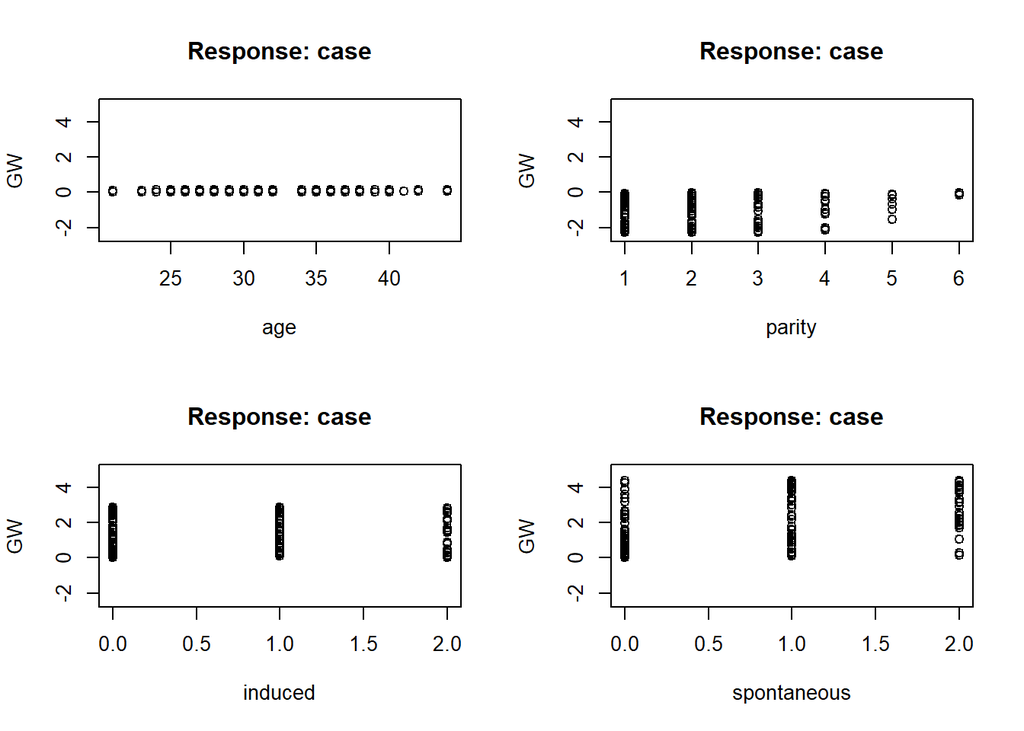

```r
par(mfrow = c(2, 2))  # 일반화가중치 시각화
gwplot(net.infert, selected.covariate = "age", min = -2.5, max = 5)
gwplot(net.infert, selected.covariate = "parity", min = -2.5, max = 5)
gwplot(net.infert, selected.covariate = "induced", min = -2.5, max = 5)
gwplot(net.infert, selected.covariate = "spontaneous", min = -2.5, max = 5)
```

- 일반화가중치 : 각 공변량들의 효과를 나타냄
  - 로지스틱 회귀에서 회귀계수와 유사하게 해석되나 각 자료점에서 국소적인 기여도를 나타냄
    - 작은 분산은 선형효과 / 큰 분산은 관측값 공간상에서 변화가 심함 > 비선형적인 효과가 있음을 나타냄
- 해석 plot 1) 일반화 가중치가 변화가 없으므로 나이변수는 y값에 큰 영향을 미치지 않는다. plot 2) 자녀수에 대해서는 음으로 기여하는 비슷한 산포가 나타난다. 각 기여도는 weight의 넓이에 비례하여 1 > 2 > … > 6이다.

  plot 3, 4) 일반화 가중치의 분산이 1보다 크므로 비선형 효과를 가진다.

  $\rightarrow$ 모형 단순화를 위해 age 제외한 3개 변수로 신경망 모형 적합 가능함

```r
# compute() : 각 뉴런의 출력값 계산
new.output = compute(net.infert, covariate = matrix(c(22, 1, 1, 0,
                                                      22, 1, 1, 0,
                                                      22, 1, 0, 1,
                                                      22, 1, 1, 1),
                                                    byrow = TRUE, ncol = 4))
new.output$net.result  # 공변량 조합에 대한 예측결과
```

```
##           [,1]
## [1,] 0.1957469
## [2,] 0.1957469
## [3,] 0.3118535
## [4,] 0.8523730
```

- 사전 낙태의 수에 따라 예측 확률이 증가함(인공1, 자연1이 불임확률 제일 높음)
- confidence.interval() : 가중치에 대한 신뢰구간
- 다층신경망 : 2개 이상의 은닉층을 가지는 구조
  - 목적 : 입력벡터 x를 출력벡터 y로 맵핑하는 것
  - 구조
    1. 입력층 : 자료벡터, 패턴 받아들임
    2. 은닉층 : 이전층으로부터 출력을 받아 가중을 취한 후 비선형의 활성함수로 넘김
    3. 출력층 : 최종 은닉층으로부터 결과를 받아 비선형적으로 결과를 넘겨 목표값을 제공
  - 은닉층의 한계
    1. 과적합 문제
    2. 학습이 제대로 이루어지지 x(훈련이 어려움)
    3. 많다고 해서 성능이 개선되지는 않음
  - 가중치는 학습과정에서 오차의 역전파 알고리즘을 통해 갱신됨
- 단층 vs 다층 : 다층신경망으로 갈수록 더 복잡한 결정 경계면을 만들어낼 수 있어 더 정확한 예측이 가능해짐

### 예제 3. neuralnet(){neuralnet}

```r
set.seed(100)
library(neuralnet)
train.input = as.data.frame(runif(50, min = 0, max = 100))
train.output = sqrt(train.input)
train.data = cbind(train.input, train.output)
colnames(train.data) = c("Input", "Output")
head(train.data)
```

```
##       Input   Output
## 1 30.776611 5.547667
## 2 25.767250 5.076145
## 3 55.232243 7.431840
## 4  5.638315 2.374514
## 5 46.854928 6.845066
## 6 48.377074 6.955363
```

```r
net.sqrt = neuralnet(Output ~ Input, train.data, hidden = 10, threshold = 0.01)  # 은닉층 1개
print(net.sqrt)
```

```
## $call
## neuralnet(formula = Output ~ Input, data = train.data, hidden = 10,
##     threshold = 0.01)
##
## $response
##      Output
## 1  5.547667
## 2  5.076145
## 3  7.431840
## 4  2.374514
## 5  6.845066
## 6  6.955363
## 7  9.013338
## 8  6.085397
## 9  7.392960
```

[output cut: 383 more lines]

```r
plot(net.sqrt)  # 시각화

test.data = as.data.frame((1:10)^2)
test.out = compute(net.sqrt, test.data)  # 신경망 모형 적용
ls(test.out)
```

```
## [1] "net.result" "neurons"
```

```r
print(test.out$net.result)
```

```
##            [,1]
##  [1,] -1.364905
##  [2,]  1.643448
##  [3,]  3.027519
##  [4,]  3.999479
##  [5,]  4.998443
##  [6,]  6.002353
##  [7,]  7.000598
##  [8,]  7.994956
##  [9,]  9.006452
## [10,]  9.965832
```

```r
net2.sqrt = neuralnet(Output ~ Input, train.data, hidden = c(10, 8), threshold = 0.01)  # 은닉층 2개
plot(net2.sqrt)
test2.out = compute(net2.sqrt, test.data)
print(test2.out$net.result)
```

```
##           [,1]
##  [1,] 1.806640
##  [2,] 2.130894
##  [3,] 2.956514
##  [4,] 4.003326
##  [5,] 5.003654
##  [6,] 5.998270
##  [7,] 7.002723
##  [8,] 7.996660
##  [9,] 9.001873
## [10,] 9.987339
```

- set.seed() : 초기값 설정, 일정한 결과 제공
- threshold = 오차함수의 편미분에 대한 값으로 정지규칙으로 사용